# DESeq analiza

Kuzman Consulting

2026-05-04

## Cilj analize

Želimo testirati koji su geni diferencijalno eksprimirani između uzoraka zdravih i tumorskih stanica.

## Instalacija i učitavanje paketa

Ako u konzoli vidite “*update all/some/none*”, pritisnite “n” i “Enter”.

```r
## CRAN paketi
libraries_cran <- c("tidyverse", "openxlsx", "ggplot2", "ggrepel", "ggpubr", "eulerr", "pheatmap", "rlang")

libraries_cran_to_install <- libraries_cran[!(libraries_cran %in% installed.packages()[, "Package"])]
if(length(libraries_cran_to_install)) install.packages(libraries_cran_to_install)

## Bioconductor paketi
libraries_bioconductor <- c("GEOquery", "DESeq2", "EnhancedVolcano", "biomaRt", "clusterProfiler", "org.Hs.eg.db", "ReactomePA")

if(!require("BiocManager", quietly = TRUE)) install.packages("BiocManager")

libraries_bioconductor_to_install <- libraries_bioconductor[!(libraries_bioconductor %in% installed.packages()[, "Package"])]
if(length(libraries_bioconductor_to_install)) BiocManager::install(libraries_bioconductor)
```

```r
## učitavanje i uređivanje podataka
library(tidyverse)
library(openxlsx)

## diferencijalna ekspresija
library(GEOquery)
library(DESeq2)

## vizualizacija
library(ggplot2)
library(ggpubr)
library(ggrepel)
library(EnhancedVolcano)
library(pheatmap)

## analiza obogaćivanja gena
library(biomaRt)
library(clusterProfiler)

## anotacija ljudskog genoma
library(org.Hs.eg.db)
```

## Priprema podataka

R može učitati datoteke različitih formata, ali za mnoge javno dostupne biološke eksperimente postoji način da se učitaju direktno iz baza podataka.

R/Bioconductor paket zvan `GEOquery` služi za preuzimanje i učitavanje podataka iz GEO baze (Gene Expression Omnibus) direktno iiz R-a te ih učitava kao `ExpressionSet` ili `SummarizedExperiment` objekte.

Podaci koji se koriste u ovoj analizi su javno dostupni u Gene Expression Omnibusu: GSE81089

Preuzimanje podataka (tablica s brojem readova, metapodaci, informacije o eksperimentu).

```r
# GEO accession number eksperimenta
my_geo <- "GSE81089"
Sys.setenv(VROOM_CONNECTION_SIZE = 500000)
geo_data <- getGEO(my_geo)[[1]]
```

```
## Found 1 file(s)
```

```
## GSE81089_series_matrix.txt.gz
```

```r
# analiza fenotipske tablice/metapodataka
head(geo_data@phenoData@data)
```

```
##            title geo_accession                status submission_date
## GSM2142443 L400T    GSM2142443 Public on Jun 01 2016     May 04 2016
## GSM2142444 L401T    GSM2142444 Public on Jun 01 2016     May 04 2016
## GSM2142445 L404T    GSM2142445 Public on Jun 01 2016     May 04 2016
## GSM2142446 L406T    GSM2142446 Public on Jun 01 2016     May 04 2016
## GSM2142447 L413T    GSM2142447 Public on Jun 01 2016     May 04 2016
## GSM2142448 L414T    GSM2142448 Public on Jun 01 2016     May 04 2016
##            last_update_date type channel_count    source_name_ch1 organism_ch1
## GSM2142443      May 15 2019  SRA             1 Human NSCLC tissue Homo sapiens
## GSM2142444      May 15 2019  SRA             1 Human NSCLC tissue Homo sapiens
## GSM2142445      May 15 2019  SRA             1 Human NSCLC tissue Homo sapiens
## GSM2142446      May 15 2019  SRA             1 Human NSCLC tissue Homo sapiens
## GSM2142447      May 15 2019  SRA             1 Human NSCLC tissue Homo sapiens
## GSM2142448      May 15 2019  SRA             1 Human NSCLC tissue Homo sapiens
##                       characteristics_ch1 characteristics_ch1.1
## GSM2142443 tumor (t) or normal (n): L400T          stage tnm: 3
## GSM2142444 tumor (t) or normal (n): L401T          stage tnm: 5
## GSM2142445 tumor (t) or normal (n): L404T          stage tnm: 3
## GSM2142446 tumor (t) or normal (n): L406T          stage tnm: 1
## GSM2142447 tumor (t) or normal (n): L413T          stage tnm: 5
## GSM2142448 tumor (t) or normal (n): L414T          stage tnm: 2
##            characteristics_ch1.2    characteristics_ch1.3 characteristics_ch1.4
## GSM2142443          histology: 2 surgery date: 2006-10-05               age: 78
## GSM2142444          histology: 2 surgery date: 2006-02-28               age: 74
## GSM2142445          histology: 2 surgery date: 2006-05-16               age: 74
## GSM2142446          histology: 1 surgery date: 2006-12-11               age: 64
## GSM2142447          histology: 2 surgery date: 2006-05-09               age: 72
## GSM2142448          histology: 3 surgery date: 2006-05-17               age: 71
##            characteristics_ch1.5  characteristics_ch1.6 characteristics_ch1.7
## GSM2142443          gender: male vital date: 2010-02-19               dead: 1
## GSM2142444          gender: male vital date: 2011-05-01               dead: 1
## GSM2142445        gender: female vital date: 2012-09-19               dead: 1
## GSM2142446          gender: male vital date: 2013-04-28               dead: 0
## GSM2142447        gender: female vital date: 2008-02-03               dead: 1
## GSM2142448          gender: male vital date: 2008-09-09               dead: 1
##            characteristics_ch1.8 characteristics_ch1.9
## GSM2142443            smoking: 3             ps who: 1
## GSM2142444            smoking: 2             ps who: 1
## GSM2142445            smoking: 2             ps who: 0
## GSM2142446            smoking: 1             ps who: 0
```

[output cut: 134 more lines]

```
## GSM2142448                 NONE      71        1       male             3
##            ps who:ch1 smoking:ch1 stage tnm:ch1 surgery date:ch1
## GSM2142443          1           3             3       2006-10-05
## GSM2142444          1           2             5       2006-02-28
## GSM2142445          0           2             3       2006-05-16
## GSM2142446          0           1             1       2006-12-11
## GSM2142447          0           2             5       2006-05-09
## GSM2142448          0           1             2       2006-05-17
##            tumor (t) or normal (n):ch1 vital date:ch1
## GSM2142443                       L400T     2010-02-19
## GSM2142444                       L401T     2011-05-01
## GSM2142445                       L404T     2012-09-19
## GSM2142446                       L406T     2013-04-28
## GSM2142447                       L413T     2008-02-03
## GSM2142448                       L414T     2008-09-09
```

### Uređivanje podataka

**`Tidyverse`** je skup međusobno povezanih R paketa osmišljenih za jednostavno, čitljivo i konzistetno rukovanje podacima. Glavna ideja tidyverse pristupa je da se svi koraci analize (čišćenja podataka, transformacije, vizualizacije,…) mogu izvesti kroz jedinstvenu logiku i sintaksu.

Neki od ključnih tidyverse paketa su:

- **dplyr** – manipulacija i filtriranje podataka
- **tidyr** – preoblikovanje podataka (pivotiranje, razdvajanje, spajanje)
- **ggplot2** – vizualizacija podataka
- **readr** – učitavanje podataka
- **stringr**, **forcats** i **lubridate** – rad s tekstom, kategorijama i datumima

Također sadrži i takozvani *pipe* operator (`%>%`) koji omogućuje jednostavno spajanje više naredbi u jasan niz koraka (rezultat jedne funkcije automatski postaje ulazni argument sljedeće), te omogućuje jednostavno čitanje kod s lijeva na desno. Kratica za `%>%` je ctrl+alt+M

Za početak ćemo odabrati varijable od interesa i urediti njihove nazive.

```r
## popis varijabli koje želimo zadržati
keep_cols <- c(
  "title",
  "geo_accession",
  "age:ch1",                      ## dob pacijenta
  "dead:ch1",                     ## status (0 - živ, 1 - preminuo)
  "gender:ch1",                   ## spol
  "histology:ch1",                ## histološka klasifikacija tumora (podtip raka)
  "ps who:ch1",                   ## WHO procjena općeg funkcionalnog stanja
  "smoking:ch1",                  ## pušački status
  "stage tnm:ch1",                ## stadij tumora
  "tumor (t) or normal (n):ch1"
)

## iz naših metapodataka, odaberi samo zadane varijable

# Select certain columns
metadata <- geo_data@phenoData@data %>%
  dplyr::select(all_of(keep_cols))

names(metadata)
```

```
##  [1] "title"                       "geo_accession"
##  [3] "age:ch1"                     "dead:ch1"
##  [5] "gender:ch1"                  "histology:ch1"
##  [7] "ps who:ch1"                  "smoking:ch1"
##  [9] "stage tnm:ch1"               "tumor (t) or normal (n):ch1"
```

Uređivanje naziva varijabli/stupaca:

```r
names(metadata) <- names(metadata) %>%
  stringr::str_remove(":ch1") %>%
  stringr::str_replace(" ", "_")

metadata <- dplyr::rename(metadata, "sample" = "tumor_(t) or normal (n)")

names(metadata)
```

```
##  [1] "title"         "geo_accession" "age"           "dead"
##  [5] "gender"        "histology"     "ps_who"        "smoking"
##  [9] "stage_tnm"     "sample"
```

Nakon što smo ispravili nazive varijabli, provjerit ćemo njihove tipove. Postoji nekoliko korisnih funkcija koje možemo iskoristiti za to.

```r
## sažeti popis svih varijabli, njihov tip i prvih nekoliko vrijednosti
str(metadata)
```

```
## 'data.frame':    218 obs. of  10 variables:
##  $ title        : chr  "L400T" "L401T" "L404T" "L406T" ...
##  $ geo_accession: chr  "GSM2142443" "GSM2142444" "GSM2142445" "GSM2142446" ...
##  $ age          : chr  "78" "74" "74" "64" ...
##  $ dead         : chr  "1" "1" "1" "0" ...
##  $ gender       : chr  "male" "male" "female" "male" ...
##  $ histology    : chr  "2" "2" "2" "1" ...
##  $ ps_who       : chr  "1" "1" "0" "0" ...
##  $ smoking      : chr  "3" "2" "2" "1" ...
##  $ stage_tnm    : chr  "3" "5" "3" "1" ...
##  $ sample       : chr  "L400T" "L401T" "L404T" "L406T" ...
```

Pojedine varijable bi trebale biti faktori - tip varijabli koji se koristi za kategorije (npr. spol, stadij tumora i sl.). Za pojedine analize je bitno definirati varijable kao faktore kako bi one pravilo funkcionirale, pa tako i analiza diferencijalne ekspresije gena budući da se radi izmedu određenih grupa.

Funkcija `lapply()` u R-u služi za primjenu iste funkcije na svaki element liste ili vektora te uvijek vraća listu kao rezultat.

```r
## faktor varijable
factor_cols <- c("dead", "gender", "histology", "ps_who", "smoking", "stage_tnm")
metadata[, factor_cols] <- lapply(metadata[, factor_cols], as.factor)

## numerička varijabla
metadata$age <- as.numeric(metadata$age)
```

Varijabla koju smo preimenovali u *sample* sadrži informaciju je li uzorak iz turmoskog ili zdravog tkiva (ovisno o tome završava li s T ili N). Želimo zadržati i nazive pojedinih uzoraka, ali također i stvoriti novu varijablu koja označava porijeklo uzorka.

```r
head(metadata$sample)
```

```
## [1] "L400T" "L401T" "L404T" "L406T" "L413T" "L414T"
```

```r
metadata$patient <- as.factor(stringr::str_remove(metadata$sample, "T|N"))
metadata$condition <- as.factor(stringr::str_replace(metadata$sample,
                                           ".*L[0-9]+([A-Za-z]).*", "\\1"))

head(metadata$patient)
```

```
## [1] L400 L401 L404 L406 L413 L414
## 199 Levels: L400 L401 L404 L406 L413 L414 L417 L420 L439 L440 L441 L442 ... L890
```

```r
head(metadata$condition)
```

```
## [1] T T T T T T
## Levels: N T
```

Možemo primijetiti da neke vrijednosti nedostaju i, ako malo bolje proučimo podatke, shvatit ćemo da za zdrave uzorke nema unesenih podataka. Ponekad ne možemo riješiti taj problem, osim eventualno isključiti te uzorke iz daljnje analize ako su nam te varijable bitne, ali u ovom slučaju možemo ispuniti te vrijednosti jer znamo identifikatore svakog pacijenta.

```r
subset(metadata, patient == "L736")
```

```
##                           title geo_accession age dead gender histology ps_who
## GSM2142566                L736T    GSM2142566  67    0   male         1      0
## GSM2142656 matched sample_L736N    GSM2142656  NA <NA>   <NA>      <NA>   <NA>
##            smoking stage_tnm sample patient condition
## GSM2142566       1         1  L736T    L736         T
## GSM2142656    <NA>      <NA>  L736N    L736         N
```

Funkcija `fill()` Ispunjuje nedostajuće vrijednosti u onim varijablama koje navedemo, tražeći vrijednosti s kojima ih treba ispuniti u smjeru koji definiramo u paramteru `.direction`.

```r
metadata <- metadata %>%
  ## grupiraj redove po šifri pacijenta
  group_by(patient) %>%
  ## ispuni nedostajuće vrijednosti za svaki par
  tidyr::fill(age, dead, gender, ps_who, smoking, .direction = "downup") %>%
  ungroup()

## provjera na jednom pacijentu
subset(metadata, patient == "L736")
```

```
## # A tibble: 2 × 12
##   title      geo_accession   age dead  gender histology ps_who smoking stage_tnm
##   <chr>      <chr>         <dbl> <fct> <fct>  <fct>     <fct>  <fct>   <fct>
## 1 L736T      GSM2142566       67 0     male   1         0      1       1
## 2 matched s… GSM2142656       67 0     male   <NA>      0      1       <NA>
## # ℹ 3 more variables: sample <chr>, patient <fct>, condition <fct>
```

Neke vrijednosti varijable *dead* nedostaju, ali nisu zabilježne kao `NA`, već kao tekstualni tip “n/a”.

```r
## koliko pacijenata je u svakoj kategoriji
table(metadata$dead, useNA = "ifany")
```

```
##
##   0   1 n/a
## 116 101   1
```

```r
metadata <- metadata %>%
  dplyr::mutate(dead = na_if(dead, "n/a"))
```

Završna provjera:

```r
summary(subset(metadata, condition == "T"))
```

```
##     title           geo_accession           age          dead        gender
##  Length:199         Length:199         Min.   :45.00   0   :105   female:103
##  Class :character   Class :character   1st Qu.:63.50   1   : 93   male  : 96
##  Mode  :character   Mode  :character   Median :69.00   n/a :  0
##                                        Mean   :67.93   NA's:  1
##                                        3rd Qu.:74.00
##                                        Max.   :84.00
##
##  histology ps_who  smoking stage_tnm    sample             patient    condition
##  1: 67     0:120   1:96    1:70      Length:199         L400   :  1   N:  0
##  2:108     1: 77   2:84    2:45      Class :character   L401   :  1   T:199
##  3: 24     2:  2   3:19    3:25      Mode  :character   L404   :  1
##                            4:23                         L406   :  1
##                            5:33                         L413   :  1
##                            7: 3                         L414   :  1
##                                                         (Other):193
```

```r
table(metadata$condition)
```

```
##
##   N   T
##  19 199
```

### Učitavanje read count tablice

Također je moguće učitati i dodatne podatke koje su autori učinili dostupnim u sklopu projekta - u ovom slučaju moguće je učitati odmah i tablicu s brojem readova za svaki gen i sve uzorke.

```r
# dodatni dostipni podaci
geo_supplemental_files  <- getGEOSuppFiles(my_geo)
counts <- read.table(rownames(geo_supplemental_files)[2], header = TRUE, sep = "\t")

rownames(counts) <- counts$Ensembl_gene_id
counts$Ensembl_gene_id <- NULL
counts[1:5, 1:5]
```

```
##                 L400T L401T L404T L406T L413T
## ENSG00000000003  6364  5953  3179  3617  5363
## ENSG00000000005    17     1     4     0   131
## ENSG00000000419  2255  3068  2342  3264  2843
## ENSG00000000457  1941  1317  1931  1473  1285
## ENSG00000000460   653  1083  1225  1101   687
```

Provjera koliko uzoraka i gena imamo:

```r
## uklanjanje redaka s nedostajućim vrijednostima
counts <- counts[complete.cases(counts), ]
dim(counts)
```

```
## [1] 63151   218
```

Budući da naši metapodaci sadrže informacije o svim uzorcima, a nas trenutno zanimaju samo oni s uparenim uzorcima, najprije ćemo izdvojiti pacijente s uparenim uzorcima:

```r
normal_samples <- subset(metadata, condition == "N")$patient
paired_samples <- subset(metadata, patient %in% normal_samples)
paired_samples
```

```
## # A tibble: 38 × 12
##    title geo_accession   age dead  gender histology ps_who smoking stage_tnm
##    <chr> <chr>         <dbl> <fct> <fct>  <fct>     <fct>  <fct>   <fct>
##  1 L511T GSM2142481       56 0     female 2         0      3       5
##  2 L532T GSM2142485       69 1     female 3         1      2       1
##  3 L561T GSM2142497       62 0     female 2         1      1       1
##  4 L563T GSM2142498       61 1     female 1         0      1       4
##  5 L566T GSM2142500       58 0     male   2         0      2       2
##  6 L572T GSM2142504       58 0     male   1         1      1       1
##  7 L606T GSM2142520       55 0     male   2         0      2       1
##  8 L616T GSM2142525       54 1     male   2         0      1       1
##  9 L644T GSM2142537       67 1     male   1         1      1       1
## 10 L656T GSM2142541       58 0     male   2         0      1       1
## # ℹ 28 more rows
## # ℹ 3 more variables: sample <chr>, patient <fct>, condition <fct>
```

Također trebamo odabrati samo te uzorke iz tablice s brojem readova:

```r
counts_ps <- counts[, paired_samples$sample]
dim(counts_ps)
```

```
## [1] 63151    38
```

Jako je bitno da nam se nazivi stupaca od tablice s brojem *readova* (nazivi uzoraka) podudaraju s nazivima redova u našim metapodacima. To znači da su uzorci u obje tablice poredanim istim redoslijedom - bitno da pripišemo ispravne metapodatke svakom pacijentu.

```r
rownames(paired_samples) <- paired_samples$sample
all(rownames(paired_samples) == colnames(counts_ps))
```

```
## [1] TRUE
```

### Vizualne provjere naših uzoraka:

Izračun veličine biblioteke svakog uzorka:

```r
lib_sizes <- colSums(counts_ps)

sample_lib_size <- data.frame(
  sample = names(lib_sizes),
  library_size = lib_sizes
)
```

Vizualizacija veličine biblioteke:

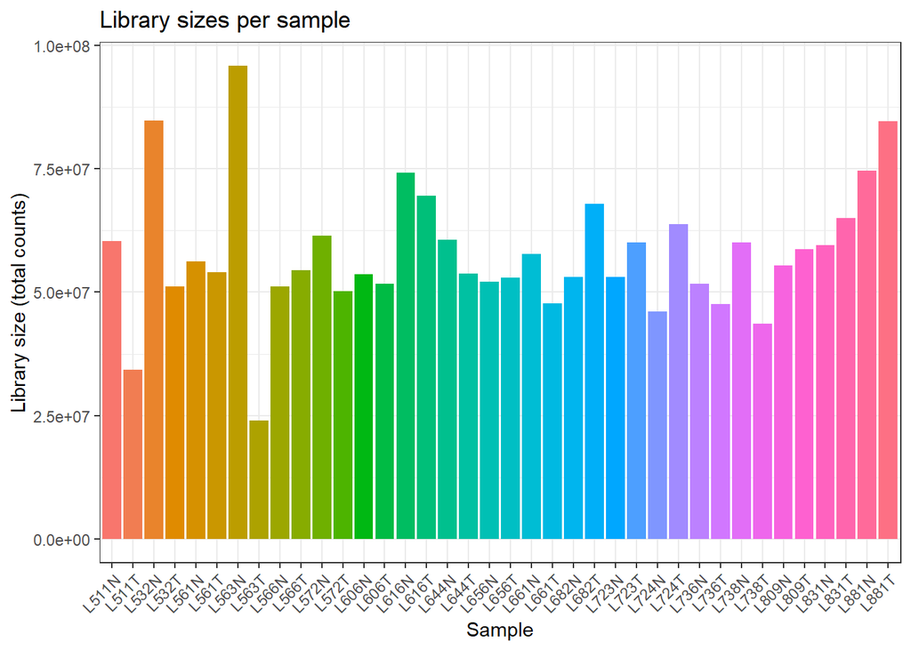

```r
ggplot(sample_lib_size, aes(x = sample, y = library_size, fill = sample)) +
  geom_col() +
  labs(
    x = "Sample",
    y = "Library size (total counts)",
    title = "Library sizes per sample"
  ) +
  theme_bw() +
  theme(legend.position = "none") +
  theme(axis.text.x = element_text(angle = 45, hjust = 1))
```

## DESeq2 analiza

R paket DESeq2 služi za analizu diferencijalno eksprimiranih gena. Analiza se provodi u 3 ključna koraka:

1. **normalizacija** - prilagođava sirove podatke tako da različita dubina sekvenciranja u uzorcima ne stvara prividne razlike u eksprimiranosti gena
2. **procjena šuma** - procijeni kolika su prirodna odstupanja i biološki šum specifičan za svaki gen te određuje koje gene treba “tretirati strože” kako bi se spriječili lažno pozitivni rezultati
3. **Waldov test** - statistička provjera jesu li preostale razlike između grupa dovoljno velike da ih se smatra značajnima

Kao rezultat dobivamo listu gena s informacijom koliko su drugačiji u odnosu na referentnu grupu te koliko je ta razlika pouzdana.

Kreiranje DESeq2 objekta iz tablice s brojem *readova* i metapodataka:

Želimo stvoriti DESeq2 objekt koji spaja tablicu s brojem *readova* i metapodatke o uzorcima u jedinstvenu strukturu, te definira dizajn analize. Želimo testirati razliku između zdravih i tumorskih uzoraka (`condition`), ali tek nakon što kontroliramo varijabilnost koja dolazi od samog pacijenta (`patient`), odnosno pronaći razliku između tumora i zdravih tkiva, a ne između pacijenata.

Kod definiranja dizajna eksperimenta (`design`), vrlo je važno zapamtiti da grupa na temelju koje želimo pronaći razlike (u ovom slučaju `condition`) **mora biti navedena posljednja**. Sve ostale grupe koje navedemo prije su razlike koje želimo uzeti u obzir i za koje želimo korigirati prilikom analize diferencijalne ekspresije gena.

```r
deseq_dataset <- DESeqDataSetFromMatrix(
  countData = counts_ps,
  colData = paired_samples,
  design = ~ patient + condition
)
```

```
## factor levels were dropped which had no samples
```

Filtriranje gena prema minimalnom broju očitanja kako bi uklonili gene s vrlo slabom ekspresijom i ostavili samo one koji imaju dovoljno podataka da DESeq2 može pouzdano procijeniti razlike u ekspresiji.

Zadržat ćemo samo one gene koji imaju ukupno 10 ili više readova u svim uzorcima.

```r
genes_to_keep <- rowSums(counts(deseq_dataset)) >= 10
table(genes_to_keep)
```

```
## genes_to_keep
## FALSE  TRUE
## 26577 36574
```

```r
deseq_dataset_subset <- deseq_dataset[genes_to_keep, ]
```

Za početak želimo provjeriti kako se grupiraju naši uzorci s obzirom na razne varijable. Idealno će se razdvajati na temelju grupe od glavnog interesa, a neće na temelju onih koje bi mogle ukazivati na *batch effect*.

Transformacije smanjuju utjecaj šuma kod nisko izraženih gena i izjednačavaju varijabilnost. Time vizualizacije poput PCA i heatmap-a postaju jasnije, a razlike među uzorcima prikazuju stvarne biološke razlike.

Transformacija broja *readova* za za PCA plot.

```r
vsd <- vst(deseq_dataset_subset, blind = TRUE)
```

Izrada **PCA plota** na temelju varijance-stabiliziranih podataka

```r
interesting_variables <- c("condition", "histology", "dead", "age", "gender", "ps_who", "smoking", "stage_tnm")
pcaData <- plotPCA(vsd, intgroup = interesting_variables, returnData = TRUE)
```

```
## using ntop=500 top features by variance
```

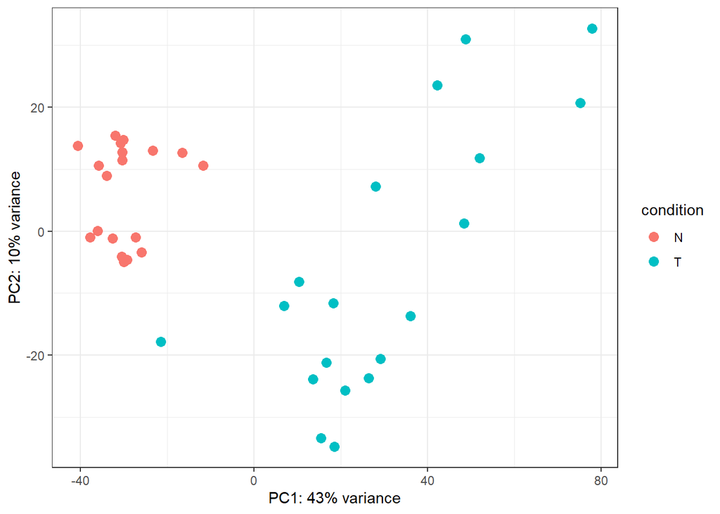

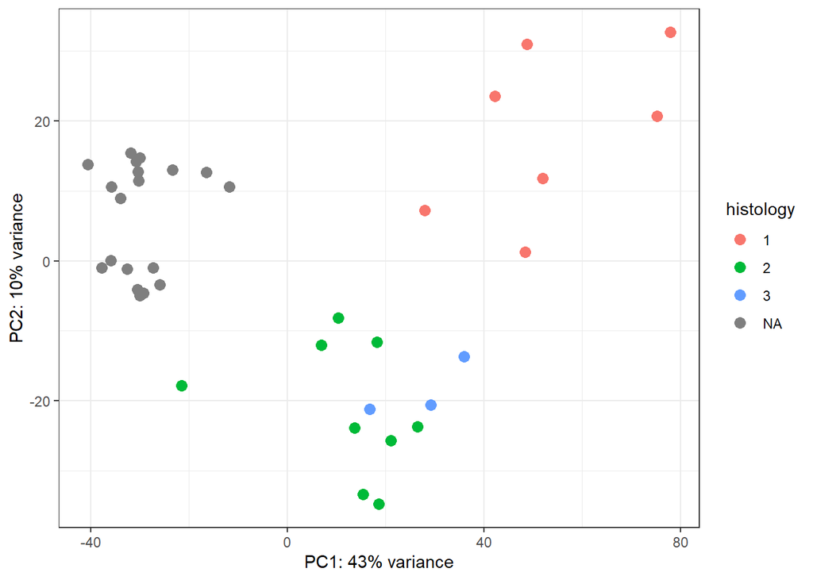

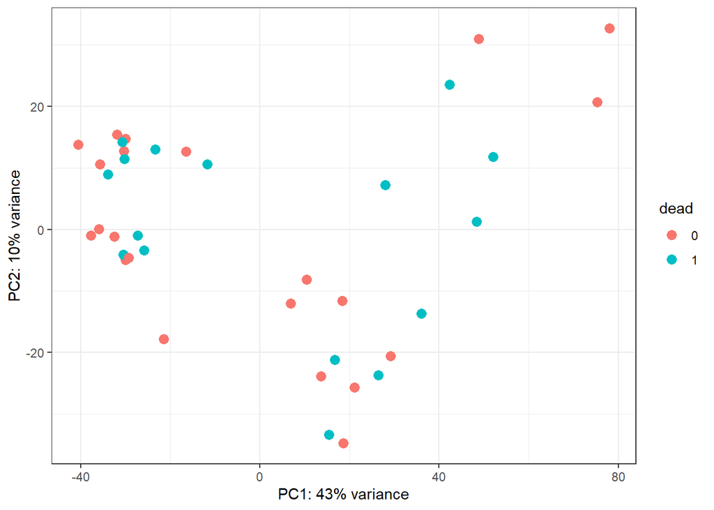

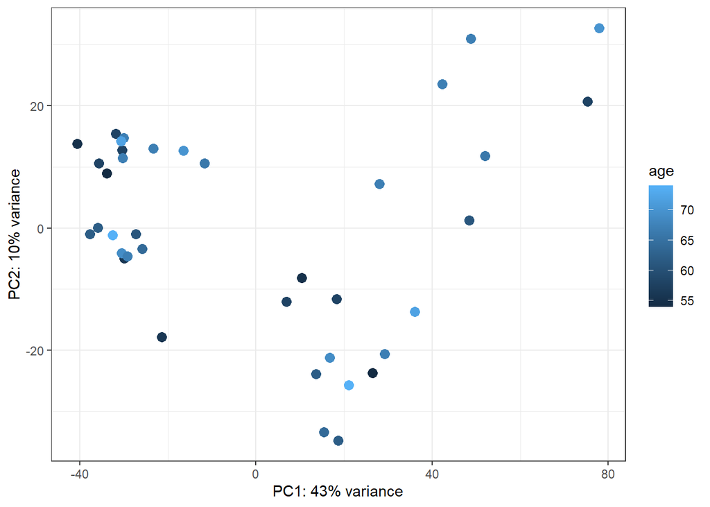

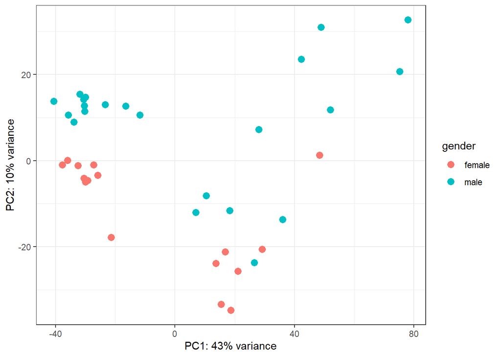

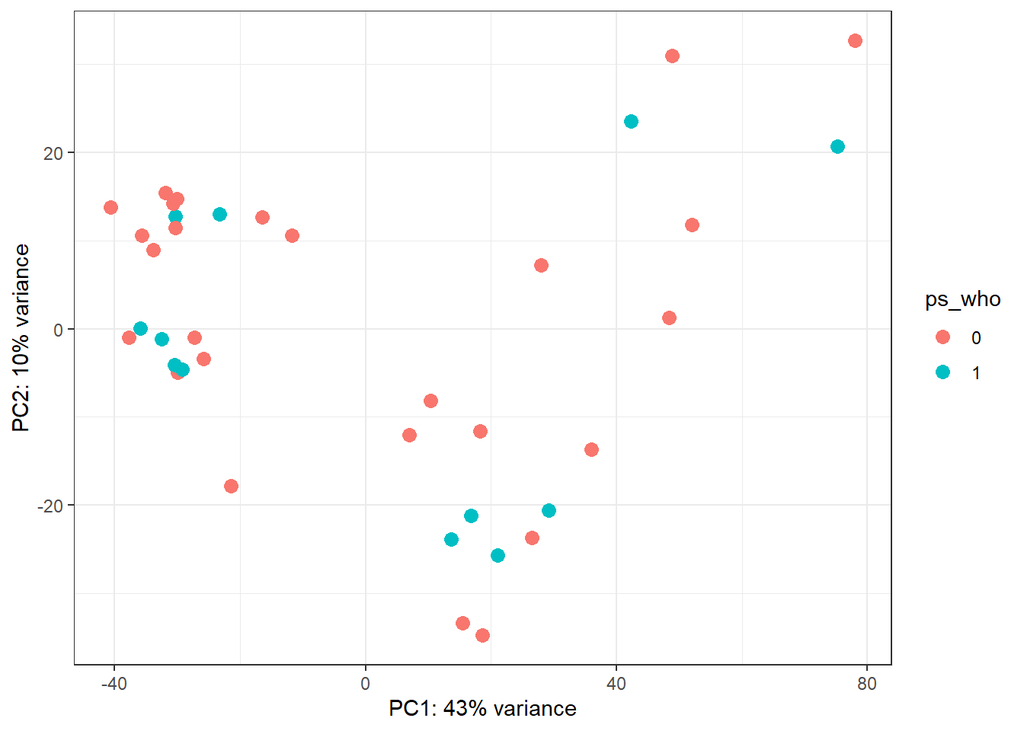

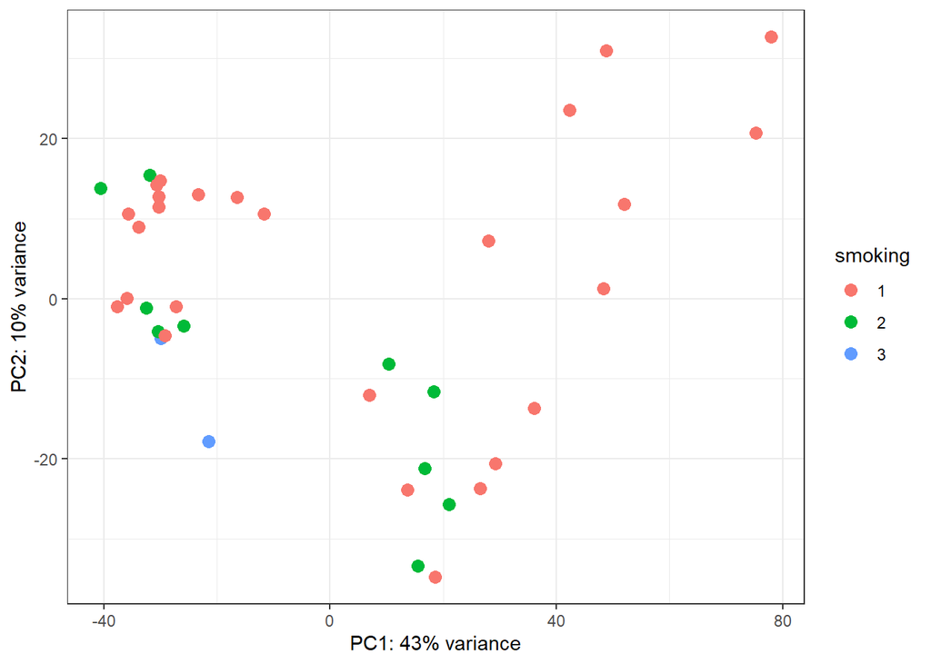

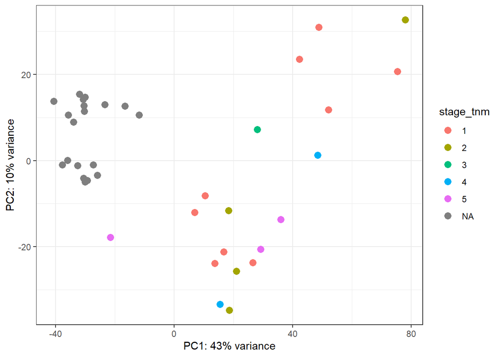

```r
percentVar <- round(100 * attr(pcaData, "percentVar"))


lapply(interesting_variables, function(var) {
  ggplot(pcaData, aes(PC1, PC2, color = get(var))) +
    geom_point(size = 3) +
    xlab(paste0("PC1: ", percentVar[1], "% variance")) +
    ylab(paste0("PC2: ", percentVar[2], "% variance")) +
    labs(
      color = var
    ) +
    theme_bw()
})
```

Pokretanje diferencijalne analize ekspresije:

Jedna funkcija pokreće analizu i odrađuje sve potrebne korake u pozadini (normalizacija, modeliranje, testiranje).

```r
deseq <- DESeq(deseq_dataset_subset)
res <- results(deseq, alpha = 0.05)
```

Analiza rezultata:

```r
head(res)
```

```
## log2 fold change (MLE): condition T vs N
## Wald test p-value: condition T vs N
## DataFrame with 6 rows and 6 columns
##                  baseMean log2FoldChange     lfcSE      stat      pvalue
##                 <numeric>      <numeric> <numeric> <numeric>   <numeric>
## ENSG00000000003 2623.4276       1.193999  0.180905   6.60016 4.10709e-11
## ENSG00000000005    1.4012      -1.742774  1.104844  -1.57739 1.14705e-01
## ENSG00000000419 2603.0099       0.530716  0.126725   4.18794 2.81493e-05
## ENSG00000000457 1124.4479       0.155356  0.080742   1.92411 5.43414e-02
## ENSG00000000460  759.9581       1.187378  0.156548   7.58476 3.33101e-14
## ENSG00000000938 3440.3542      -2.154617  0.164498 -13.09816 3.37330e-39
##                        padj
##                   <numeric>
## ENSG00000000003 4.69520e-10
## ENSG00000000005          NA
## ENSG00000000419 1.21139e-04
## ENSG00000000457 1.00593e-01
## ENSG00000000460 5.87370e-13
## ENSG00000000938 1.09291e-36
```

```r
summary(res)
```

```
##
## out of 36574 with nonzero total read count
## adjusted p-value < 0.05
## LFC > 0 (up)       : 7513, 21%
## LFC < 0 (down)     : 6619, 18%
## outliers [1]       : 0, 0%
## low counts [2]     : 7091, 19%
## (mean count < 1)
## [1] see 'cooksCutoff' argument of ?results
## [2] see 'independentFiltering' argument of ?results
```

Filtriranje statistički značajnih gena prema p-vrijednosti i log2FC-u:

```r
res_sig <- subset(res, padj < 0.05 & abs(log2FoldChange) > 1)
nrow(res_sig)
```

```
## [1] 7211
```

```r
head(res_sig)
```

```
## log2 fold change (MLE): condition T vs N
## Wald test p-value: condition T vs N
## DataFrame with 6 rows and 6 columns
##                  baseMean log2FoldChange     lfcSE      stat      pvalue
##                 <numeric>      <numeric> <numeric> <numeric>   <numeric>
## ENSG00000000003 2623.4276        1.19400  0.180905   6.60016 4.10709e-11
## ENSG00000000460  759.9581        1.18738  0.156548   7.58476 3.33101e-14
## ENSG00000000938 3440.3542       -2.15462  0.164498 -13.09816 3.37330e-39
## ENSG00000001084 6508.0590        1.39841  0.341192   4.09860 4.15664e-05
## ENSG00000001626 3111.7999       -3.10984  0.422572  -7.35931 1.84860e-13
## ENSG00000002079   14.4705        1.68988  0.367177   4.60235 4.17748e-06
##                        padj
##                   <numeric>
## ENSG00000000003 4.69520e-10
## ENSG00000000460 5.87370e-13
## ENSG00000000938 1.09291e-36
## ENSG00000001084 1.72582e-04
## ENSG00000001626 2.92708e-12
## ENSG00000002079 2.10502e-05
```

Koje uvjete mora gen zadovoljiti da bi ga smatrali značajnim? Prema ovim kriterijima - mora imati korigiranu p-vrijednost manju od 0.05 i apsolutnu vrijednost *log2 fold change*-a veću od 1. **Korigirana p-vrijednost** **mora** **biti manja od 0.05**, dok *log2 fold change* se može prilagođavati ovisno o tome što je predmet istraživanja i broju gena za koje je razlika značajna.

Rezultate možemo spremiti u .csv formatu za daljnje analize.

```r
write.csv(res_sig, "significant_genes.csv", row.names = TRUE)
```

## Vizualizacija rezultata

Transformacija broja *readova* za **heatmap**:

```r
ntd <- normTransform(deseq_dataset_subset)
```

Priprema anotacije uzoraka za heatmapu:

```r
ann <- as.data.frame(colData(deseq_dataset_subset)[, c("condition", "gender", "dead", "histology", "smoking", "stage_tnm")])
rownames(ann) <- rownames(colData(deseq_dataset_subset))
```

Odabir diferencijalno eksprimiranih gena za prikaz na heatmap-u:

```r
select <- rownames(subset(res, padj < 0.05 & abs(log2FoldChange) > 2))
length(select)
```

```
## [1] 2837
```

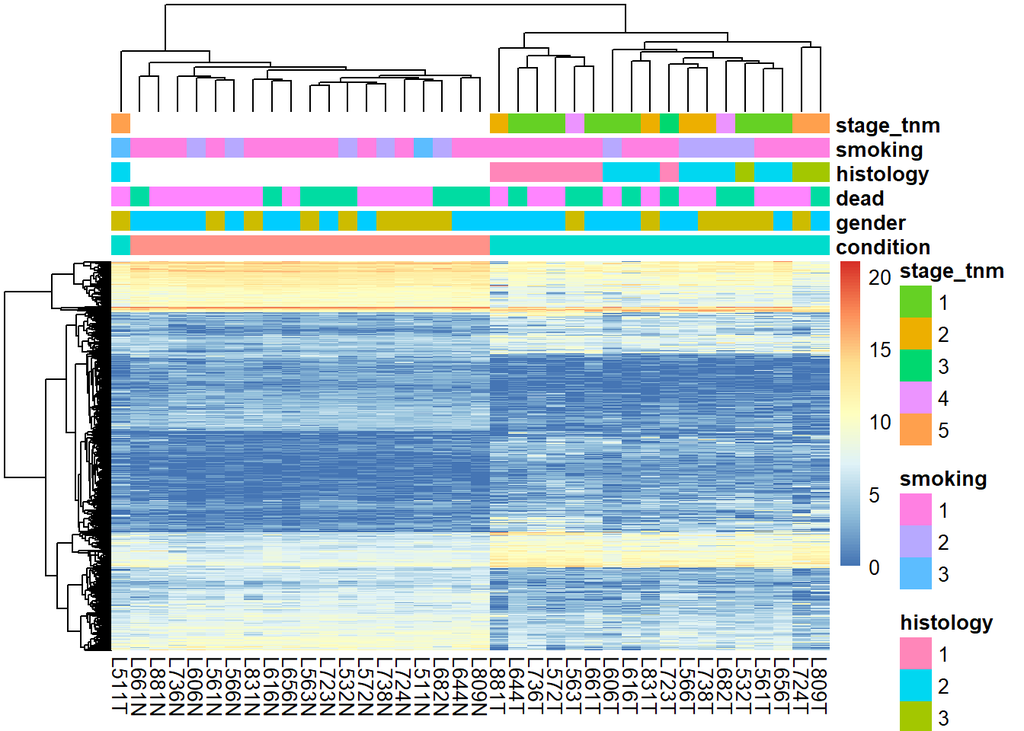

```r
pheatmap(
  mat = assay(ntd)[select, ],
  cluster_rows = TRUE,
  show_rownames = FALSE,
  cluster_cols = TRUE,
  annotation_col = ann#,
  #filename = "pheatmap.pdf"
  )
```

Kako mijenjanje granične vrijednosti za `abs(log2FoldChange)` utječe na heatmap?

Prikaz **MA plota** diferencijalne ekspresije:

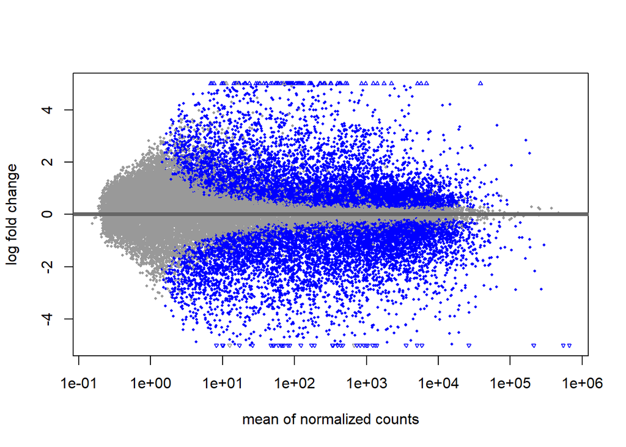

```r
plotMA(res, ylim = c(-5, 5))
```

Što sve gledamo na MA plotu?

- plave točke predstavljaju značajno diferencijalno izražene gene - ima ih mnogo kroz cijeli raspon ekspresije -> snažna razlika između zdravih i tumorskih stanica
- širina plavog oblaka:
  - nisko eksprimirani geni (lijevo) su varijabilniji i skloniji šumu
  - visoko eksprimirani geni (desno) su manje šumoviti
- simetričan raspored oko osi -> nema očite tehničke pristranosti -> dobra normalizacija

Priprema podataka za **volcano plot**:

Trenutno naša tablica s genima sadrži Ensembl indentifikatore za nazive gene, dok je uobičajenije prikazati simbole gena na određenim grafovima. Postoje razne funkcije koje automatski prevode identifikatore iz jednog formata u drugi.

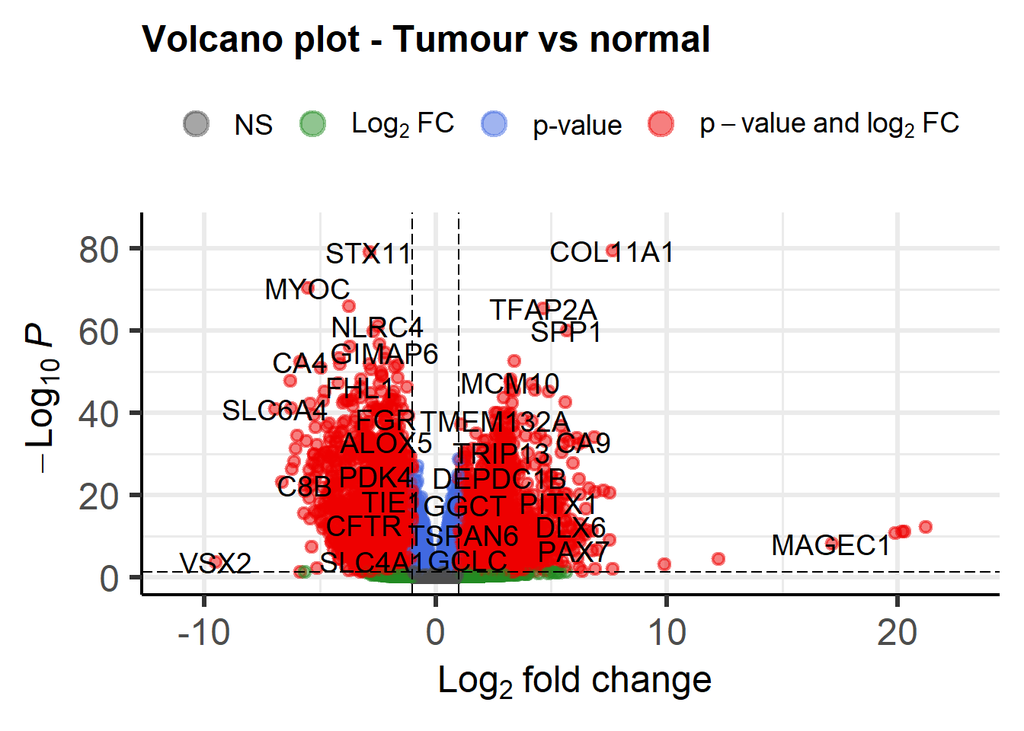

```r
padj_cut <- 0.05
lfc_cut <- 1

## prevođenje Ensembl identifikatora u simbole gena
res$symbol <- mapIds(org.Hs.eg.db,
                     keys = row.names(res),
                     column = "SYMBOL",
                     keytype = "ENSEMBL",
                     multiVals = "first")
## koristiti originalni Ensembl ID ukoliko nije pronađen simbol za neki gen
res$symbol <- ifelse(is.na(res$symbol), row.names(res), res$symbol)

## volcano plot
EnhancedVolcano(res,
                lab = res$symbol,
                x = 'log2FoldChange',
                y = 'pvalue',
                pCutoff = padj_cut,
                FCcutoff = lfc_cut,
                title = "Volcano plot - Tumour vs normal",
                subtitle = NULL,
                caption = NULL)
```

```r
ggsave("volcano_plot.png", dpi = 300, units = "in", width = 10, height = 8)
```

# Gene enrichment analiza

Otkriva koje su biološke funkcije, procesi ili putovi zastupljeni među genima. Želimo povezati rezultate koje smo dobili DESeq2 analizom s biološkim funkcijama.

### *Gene enrichement* s bazom *Gene Ontology*

Priprema podataka za analizu obogaćenja gena:

Napravit ćemo nove varijable koje će opisivati naše gene:

- `regulation`: označit ćemo imaju li geni povećanu ili smanjenu ekspresiju
- `significant`: označit ćemo je li gen statistički značajan i ima li dovoljno veliku promjenu

```r
padj_threshold <- 0.05
log2FoldChange_threshold <- 2

res <- as.data.frame(res)
res$regulation <- "Not significant"
res$regulation[res$padj < padj_threshold & res$log2FoldChange > log2FoldChange_threshold] <- "Upregulated"
res$regulation[res$padj < padj_threshold & res$log2FoldChange < -(log2FoldChange_threshold)] <- "Downregulated"

res$significant <- ifelse(res$padj < padj_threshold & abs(res$log2FoldChange) > log2FoldChange_threshold,
                             "Significant", "Not significant")

table(res$regulation)
```

```
##
##   Downregulated Not significant     Upregulated
##            1527           33737            1310
```

Odabrat ćemo 500 najznačajnijih gena s najmanjim korigiranim p-vrijednostima i koristiti samo njih kako bi sama vizualizacija bila malo brža.

Korsitit ćemo funkciju `bitr()` kako bi preveli genske simbole u ENTREZ ID (brojčani ID) te ih spojili s tablicom rezultata koju smo prethodno dobili.

Grupirat ćemo gene prema njihovoj regulaciji te analizirati koji biološki procesi su u njima obogaćeni.

```r
res_top <- res[order(res$padj), ][1:500,]
table(res_top$regulation)
```

```
##
##   Downregulated Not significant     Upregulated
##             235             125             140
```

```r
res_top <- full_join(res_top,
                     bitr(res_top$symbol, fromType = "SYMBOL", toType = c("SYMBOL", "ENTREZID"), OrgDb = org.Hs.eg.db),
                     by = c("symbol" = "SYMBOL"))
enrich_go <- compareCluster(
   ENTREZID ~ regulation, data = res_top[res_top$significant != "Not significant", ],
   fun = "enrichGO",
   OrgDb = org.Hs.eg.db,
   pAdjustMethod = "BH",
   pvalueCutoff = 0.05, qvalueCutoff = 0.05, readable = T
   )
```

Graf koji prikazuje 10 najznačajnijih procesa u našim genima za svaku grupu:

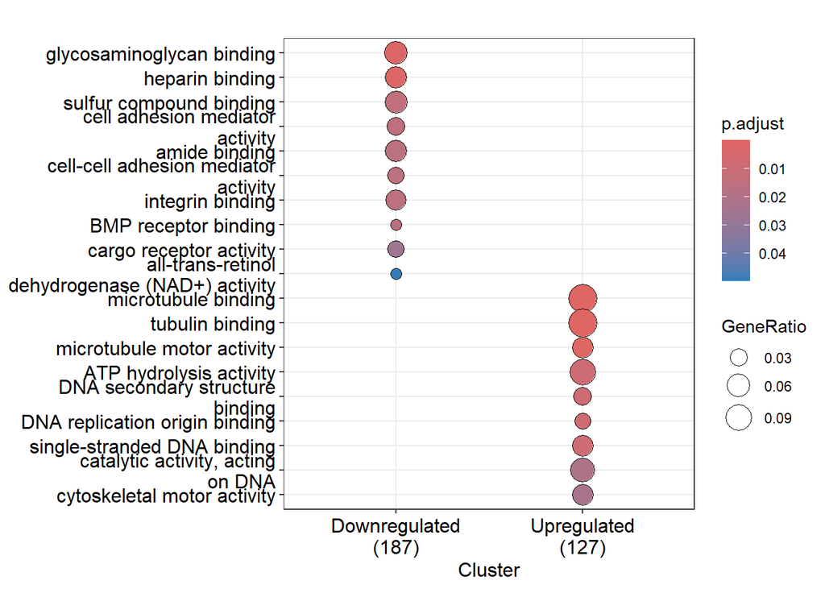

```r
dotplot(enrich_go, showCategory = 10)
```

```r
ggsave("go_dotplot.png", width = 8, height = 8, dpi = 300)
```

Kako interpretirati graf: p.adjust (boja točkice) označava statističku značajnost korigiranu za višestruko testiranje; što je točkica crvenija, manja je šansa da je rezultat slučajan. GeneRatio (veličina točkice) predstavlja udio značajnih gena koji pripadaju tom specifičnom putu u odnosu na ukupan broj mapiranih gena.

Graf koji povezuje biološke procese s genima koji ih čine - prikazat ćemo 3 najznačajnija procesa za svaku grupu prema regulaciji gena:

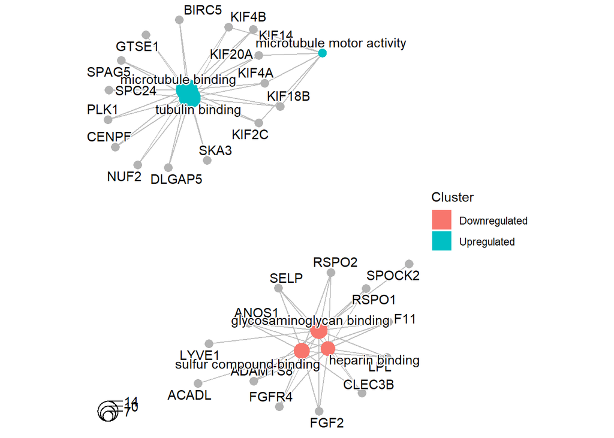

```r
cnetplot(enrich_go, showCategory = 3)
```

```r
ggsave("go_concept_network_plot.png", width = 8, height = 8, dpi = 300)
```

### *Gene enrichement* s bazom *KEGG*

*KEGG* je zbirka bioloških putova koji prikazuju kako geni, proteini i metabolički procesi međusobno surađuju u organizmu.

Na istom setu od 500 najznačajnijih gena ćemo također napraviti sličnu analizu, ali ovaj put koristeći biološke putove iz KEGG baze.

```r
kegg_comparison <- compareCluster(ENTREZID ~ regulation,
                                  data = res_top[res_top$significant != "Not significant", ],
                                  fun = "enrichKEGG",
                                  organism = "hsa",
                                  pAdjustMethod = "BH",
                                  pvalueCutoff = 0.05,
                                  qvalueCutoff = 0.05)

## pretvaranje ENTREZ identifikatora u simbole gena
kegg_comparison <- setReadable(kegg_comparison, OrgDb = org.Hs.eg.db, keyType = "ENTREZID")
```

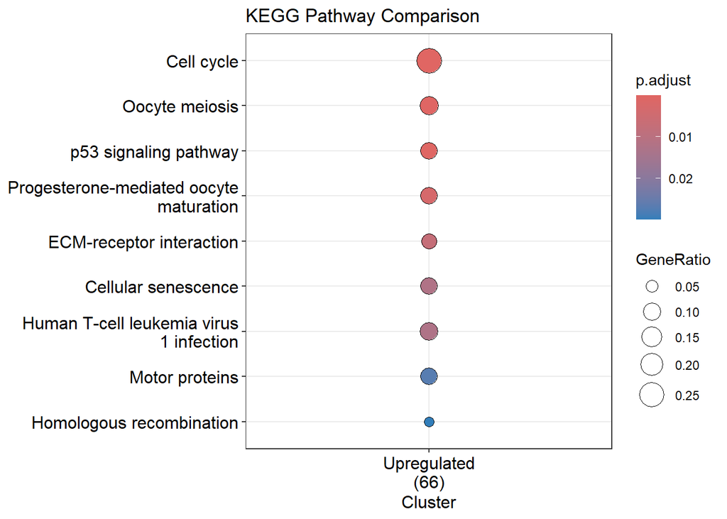

```r
dotplot(kegg_comparison, showCategory = 10, title = "KEGG Pathway Comparison")
```

```r
ggsave("kegg_dotplot.png", width = 8, height = 8, dpi = 300)
```

Graf koji povezuje biološke putoves genima koji ih čine:

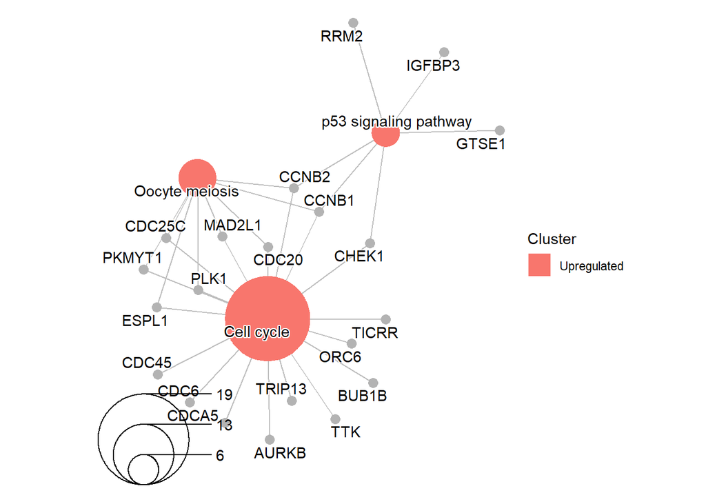

```r
cnetplot(kegg_comparison, showCategory = 3)
```

```r
ggsave("kegg_concept_network_plot.png", width = 8, height = 8, dpi = 300)
```